# Monte Carlo Investigation: The Binomial Small Population

Author

Pui Yin Lim

## 1. Population & Theoretical Baseline

- **Population Distribution:** Binomial Distribution with number of trials $size = 10$ and success probability $p = 0.5$, generated via `rbinom(n, size = 10, prob = 0.5)`.
- **Characteristics:** It is a discrete distribution bounded between $0$ and $10$. Because $p = 0.5$, it is perfectly symmetric.
- **Theoretical Mean (**$\mu$): $\mu = \text{size} \times p = 10 \times 0.5 = 5$
- **Theoretical Standard Deviation (**$\sigma$): $\sigma = \sqrt{\text{size} \times p \times (1 - p)} = \sqrt{10 \times 0.5 \times 0.5} = \sqrt{2.5} \approx 1.5811$
- **Theoretical Standard Error (**$\text{SE}$): $\frac{\sigma}{\sqrt{n}} = \frac{\sqrt{2.5}}{\sqrt{n}}$

## 2. Expectations Before Simulation

Since the underlying population is discrete and bounded, small sample sizes (like $n = 5$) should produce visibly stepped or discrete sampling distributions, but with $p = 0.5$, and a symmetric parent distribution, by transitioning through $n = 20$ which is approaching the CLT threshold and scaling up to $n = 100$ and $1000$, there should be variance contraction.

## 3. Simulation Setup & Execution

Simulating $B = 10,000$ Monte Carlo repetitions across sample sizes $n \in \{5, 20, 100, 1000\}$.

```r
library(tidyverse)
library(knitr)

binom_size <- 10
binom_prob <- 0.5
theo_sigma <- sqrt(binom_size * binom_prob * (1 - binom_prob))

# Create a data frame for the explanation table
binom_explanation_table <- tibble(
  Sample_Size = c("n = 5", "n = 20", "n = 100", "n = 1000"),
  Theoretical_SE = c("≈ 0.7071", "≈ 0.3536", "≈ 0.1581", "≈ 0.0500"),
  Interpretation = c(
    "A small sample size exhibiting prominent discrete multi-modal steps due to limited possible combinations, accompanied by a high standard error.",
    "An intermediate sample size approaching the CLT threshold where intermediate fractional means rapidly fill in gaps, smoothing out the jagged steps.",
    "A larger sample size that bridges the gap, densifying the distribution and making the bell curve visibly narrower and taller.",
    "An instance of extreme variance contraction, where the histogram becomes a sharp, needle-like peak centered tightly around μ = 5 while fully erasing discrete bounds."
  )
)

kable(
  binom_explanation_table,
  col.names = c("Sample Size", "Theoretical SE", "Description & Interpretation"),
  align = c("c", "c", "l")
)
```

Table 1: Rationale for Sample Size Selection (Binomial Population)

| Sample Size | Theoretical SE | Description & Interpretation |
| --- | --- | --- |
| n = 5 | ≈ 0.7071 | A small sample size exhibiting prominent discrete multi-modal steps due to limited possible combinations, accompanied by a high standard error. |
| n = 20 | ≈ 0.3536 | An intermediate sample size approaching the CLT threshold where intermediate fractional means rapidly fill in gaps, smoothing out the jagged steps. |
| n = 100 | ≈ 0.1581 | A larger sample size that bridges the gap, densifying the distribution and making the bell curve visibly narrower and taller. |
| n = 1000 | ≈ 0.0500 | An instance of extreme variance contraction, where the histogram becomes a sharp, needle-like peak centered tightly around μ = 5 while fully erasing discrete bounds. |

```r
library(tidyverse)
library(moments)

# Reproducible seed using last 4 digits of student ID
student_id <- 5678
set.seed(student_id)

B <- 10000                  # Number of Monte Carlo simulations
sample_sizes <- c(5, 20, 100, 1000) # Sample sizes to investigate

# Run simulation dynamically for all sample sizes using map_dfr
sim_data <- map_dfr(sample_sizes, function(n_val) {
  sample_means <- replicate(B, mean(rbinom(n_val, size = binom_size, prob = binom_prob)))
  tibble(
    n = factor(n_val, levels = sample_sizes),
    sample_mean = sample_means
  )
})
```

## 4. Visualizing

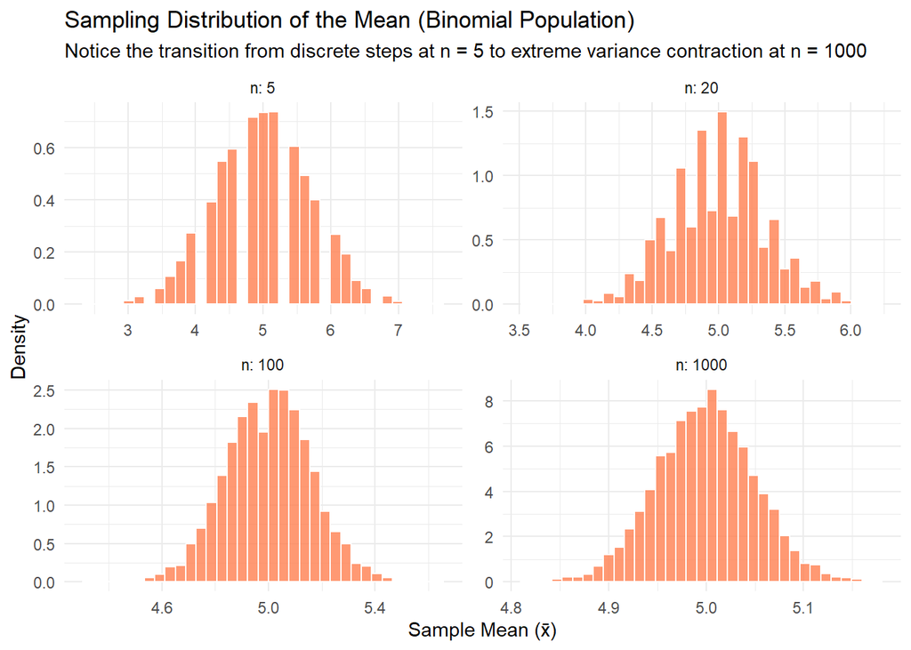

```r
ggplot(sim_data, aes(x = sample_mean)) +
  geom_histogram(aes(y = after_stat(density)), bins = 35, fill = "coral", color = "white", alpha = 0.8) +
  facet_wrap(~n, scales = "free", labeller = label_both) +
  theme_minimal() +
  labs(
    title = "Sampling Distribution of the Mean (Binomial Population)",
    subtitle = "Notice the transition from discrete steps at n = 5 to extreme variance contraction at n = 1000",
    x = "Sample Mean (x̄)",
    y = "Density"
  )
```

As $n$ grows from $5$ to $1000$, the histograms document both the Central Limit Theorem and extreme variance contraction. Because $p = 0.5$ provides absolute symmetry, the distribution bypasses directional skew, smoothly converging into a standard bell shape while the standard error shrinks down from $\approx 0.7071$ to $\approx 0.0500$.

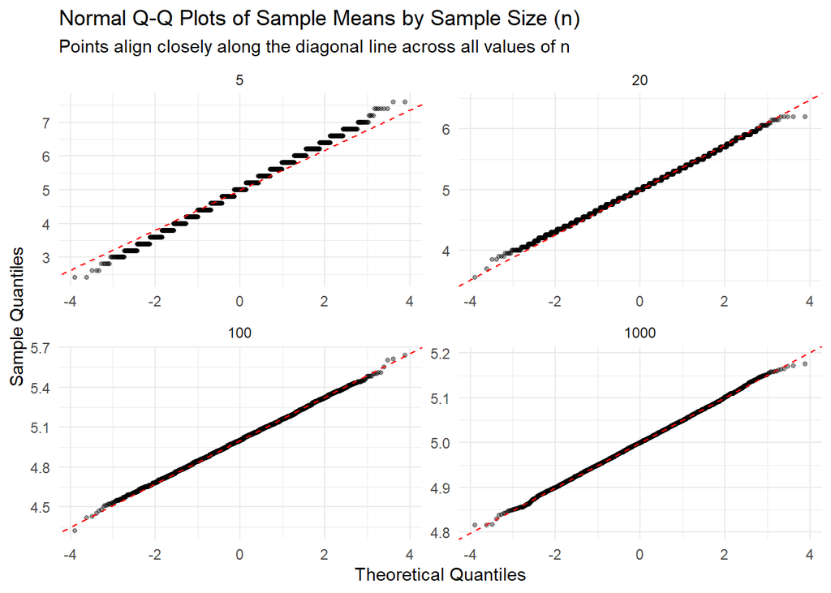

```r
library(ggplot2)

ggplot(sim_data, aes(sample = sample_mean)) +
  geom_qq(alpha = 0.4, size = 1) +
  geom_qq_line(color = "red", linetype = "dashed") +
  facet_wrap(~ n, scales = "free") +
  labs(
    title = "Normal Q-Q Plots of Sample Means by Sample Size (n)",
    subtitle = "Points align closely along the diagonal line across all values of n",
    x = "Theoretical Quantiles",
    y = "Sample Quantiles"
  ) +
  theme_minimal()
```

## 5. Numerical Output

```r
summary_table <- sim_data %>%
  group_by(n) %>%
  summarise(
    Simulated_Mean = mean(sample_mean),
    Simulated_SD = sd(sample_mean),
    "Theoretical SE (σ/√n)" = theo_sigma / sqrt(as.numeric(as.character(first(n)))),
    Skewness = moments::skewness(sample_mean),
    Kurtosis = moments::kurtosis(sample_mean)
  )

knitr::kable(
  summary_table,
  caption = "Comparison of Simulated vs. Theoretical Metrics for Binomial Population",
  digits = 4,
  align = c("c", "c", "c", "c", "c")
)
```

Comparison of Simulated vs. Theoretical Metrics for Binomial Population

| n | Simulated_Mean | Simulated_SD | Theoretical SE (σ/√n) | Skewness | Kurtosis |
| --- | --- | --- | --- | --- | --- |
| 5 | 4.9972 | 0.7063 | 0.7071 | 0.0042 | 2.9605 |
| 20 | 5.0023 | 0.3510 | 0.3536 | 0.0250 | 3.0181 |
| 100 | 5.0005 | 0.1588 | 0.1581 | -0.0003 | 3.0242 |
| 1000 | 4.9996 | 0.0501 | 0.0500 | 0.0098 | 3.0443 |

**Simulated Mean:** Stays consistently centered around $\mu = 5$ across all sample sizes, confirming that the sample mean remains an unbiased estimator for discrete distributions.

**Skewness and Kurtosis:** Skewness stays near $0$ across all sample sizes due to the symmetry of $p = 0.5$, while kurtosis holds steady around $3$ as the distribution normalizes.

## 6. In Summary

**1. What does the original population distribution look like?**

The parent population is a Binomial Distribution ($\text{size} = 10$, $p = 0.5$), which is discrete, bounded between $0$ and $10$, and perfectly symmetric.

**3. How does the simulated mean compare with the theoretical mean?**

The simulated means stay extremely close to $\mu = 5$ across all $n$ (within $\pm 0.005$), confirming unbiased behavior over $10,000$ iterations even up to $n = 1000$.

**4. How does the simulated standard error compare with $\text{SE}(\bar{x}) = \frac{\sigma}{\sqrt{n}}$?**

The simulated standard deviations track the theoretical standard error formula ($\text{SE} = \frac{\sqrt{2.5}}{\sqrt{n}}$) with high precision across all tested sample sizes.

**6. What limitations or surprises did you observe?**

The main observation is that scaling up to large sample sizes like $n = 1000$ erased the granularity of the discrete binomial population showcasing extreme variance contraction, transforming the histogram into a peak centered around $\mu = 5$ while preserving its underlying normal shape.